# STA137 Project1

Diana Rueda

10/23/2021

#### (a) Plot the data and elaborate on the general pattern of the data.

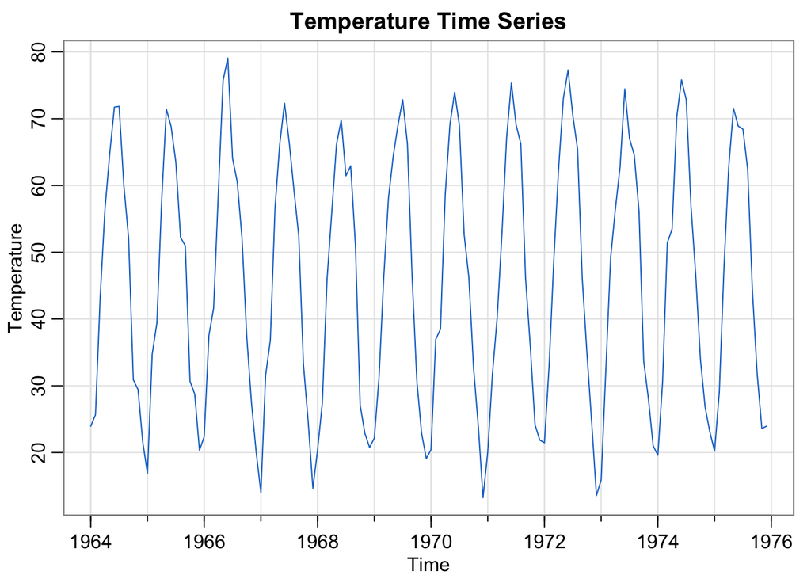

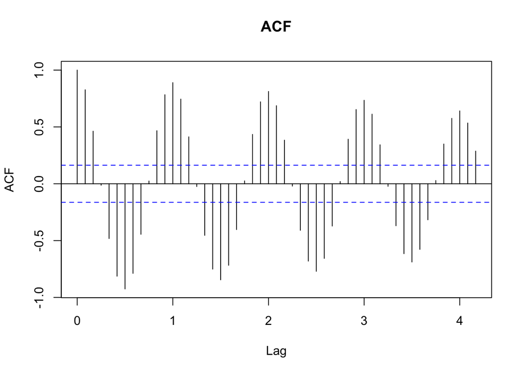

The data shows a pattern of temperature fluctuations that repeat every 12 months. This is to be expected as we are looking at the average monthly temperature of a region change with the stations. There is no identifieable trend but there is a lot of seasonality. Every year follows the same pattern of increase and decrease give or take some degrees and resets back to about the same temperatures at the beginning of the year. In addition the data seems to have a mean around 45. It is not a mean zero process and the ACF trails off very slowly in an oscilating manner from negative to positive autocorrelation values.

#### (b) Fit the regression model

```
##
## Call:
## lm(formula = temp ~ -1 + m)
##
## Residuals:
##     Min      1Q  Median      3Q     Max
## -8.5585 -2.5936  0.3811  2.4455  7.2519
##
## Coefficients:
##     Estimate Std. Error t value Pr(>|t|)
## m1    19.794      1.049   18.87   <2e-16 ***
## m2    31.867      1.049   30.37   <2e-16 ***
## m3    44.151      1.049   42.08   <2e-16 ***
## m4    57.551      1.049   54.85   <2e-16 ***
## m5    68.558      1.049   65.34   <2e-16 ***
## m6    73.044      1.049   69.62   <2e-16 ***
## m7    68.083      1.049   64.89   <2e-16 ***
## m8    60.791      1.049   57.94   <2e-16 ***
## m9    49.209      1.049   46.90   <2e-16 ***
## m10   32.741      1.049   31.20   <2e-16 ***
## m11   25.587      1.049   24.39   <2e-16 ***
## m12   19.429      1.049   18.52   <2e-16 ***
## ---
## Signif. codes:  0 '***' 0.001 '**' 0.01 '*' 0.05 '.' 0.1 ' ' 1
##
## Residual standard error: 3.635 on 132 degrees of freedom
## Multiple R-squared:  0.9951, Adjusted R-squared:  0.9947
## F-statistic:  2238 on 12 and 132 DF,  p-value: < 2.2e-16
```

#### (i) If the model is correct, determine if the average temperature increase or decrease from month to month? Determine this from January to December.

If we considere the values of the estimates from the summary table of our regression model the means of each month, then we can show the temperature change in the following table where the difference of the average temperatures from one month to the next gives us the amount of change from that month to the next.

```
##                 months avg_change
## 1   January - February  12.073366
## 2     February - March  12.283594
## 3        March - April  13.400322
## 4          April - May  11.006571
## 5           May - June   4.485746
## 6          June - July  -4.960334
## 7        July - August  -7.292544
## 8   August - September -11.581397
## 9  September - October -16.468277
## 10  October - November  -7.153682
## 11 Nobember - December  -6.158747
```

The months with a negative anerage-change in temperature are the months showing a decrease in temperature. From the plot of the time series we can see this makes sense since the slope of the line becomes negative about half way into the year and positive again around the start of the following year after reaching minimum temperatures.

#### (ii) Graph the data, 𝑥𝑡, and superimpose the fitted values, say 𝑥̂𝑡, on the graph. Examine the residuals, 𝑥𝑡−𝑥̂𝑡, and state your conclusions, Does it appear that the model fits the data well (do the residuals look white)? Justify your answer.

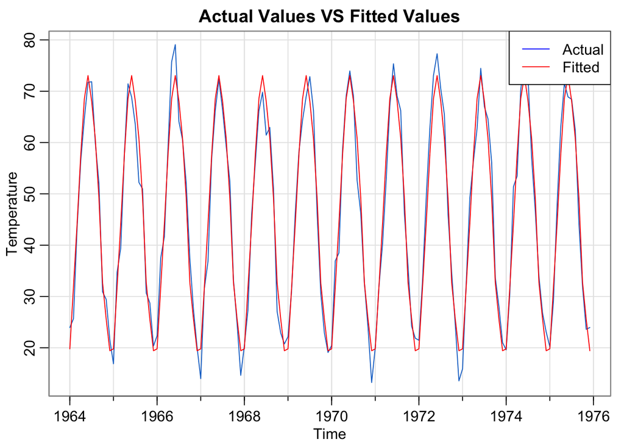

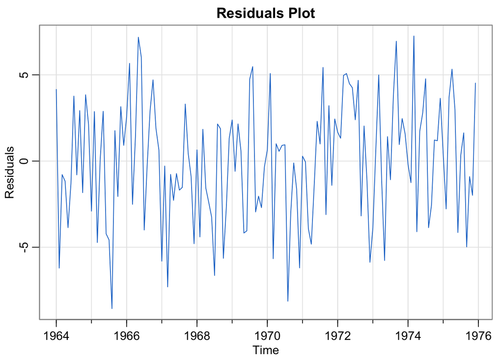

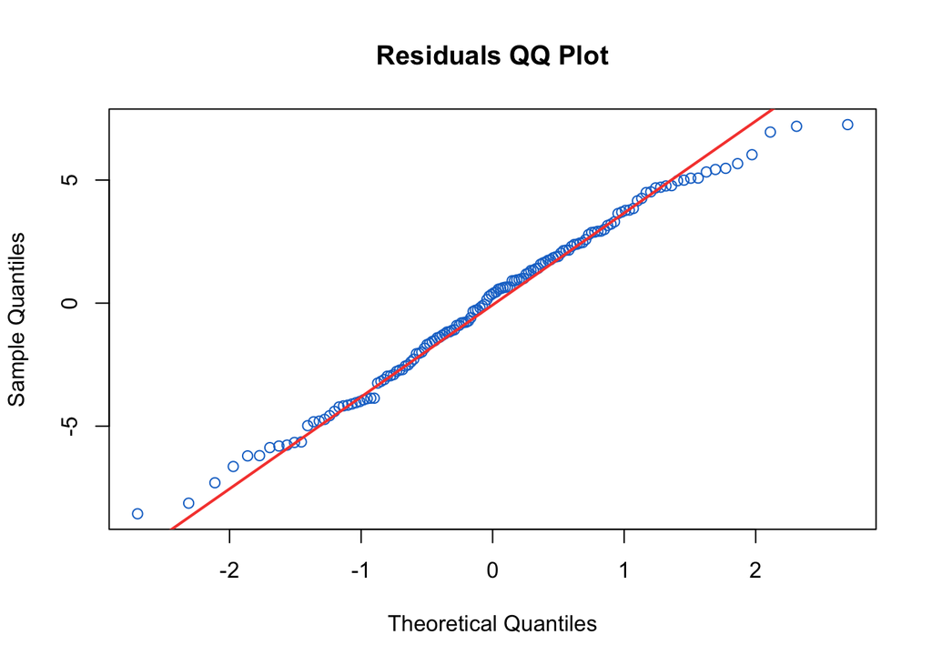

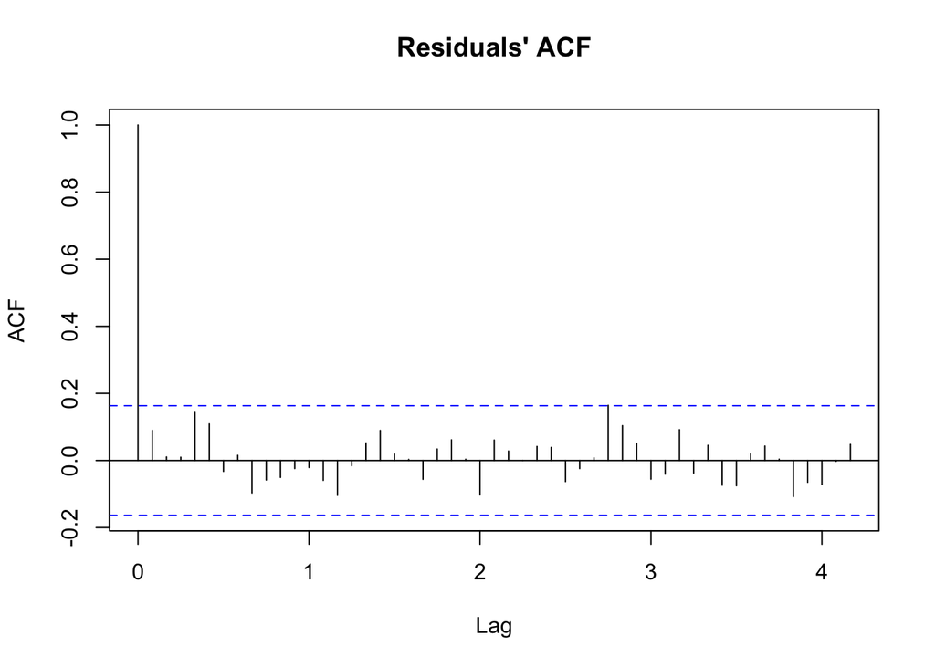

The first plot of the residuals shows what looks like random data without a pattern or seasonality. As observed in the QQ plot above the normality assumption looks reasonable. In addition, the ACf of the residuals shows that 95% of the autocorrelation spikes are within the blue lines which indicates there are no significant autocorrelations in the residuals. Thus the residuals look like white noise. The appereance of the residuals combined with the plot of Actual values vs fitted values indicate that the model fits the data well.

#### (c) In this part we try to find dominant periodic components in the data. Fit the regression model 𝑥𝑡=𝛼+∑6𝑘=1𝛽𝑘,1cos(2𝑘𝜋𝑡/12)+𝛽𝑘,2sin(2𝑘𝜋𝑡/12)+𝜔𝑡 where 𝑡=1,…,144. Note that the sin(2𝑘𝜋/12) and cos(2𝑘𝜋/12) waves repeat itself every 12/𝑘 unit time. The number 𝑓=𝑘/12, called frequency, is the number of times a sin or cosine function repeats itself.

#### (i) If the model is correct, determine the significant frequencies (at level .01) in the time series. Based on your analysis, how many months it takes for the time series to repeat itself.

```
##
## Call:
## lm(formula = temp ~ cos((2 * pi * t2)/12) + sin((2 * pi * t2)/12) +
##     cos((2 * 2 * pi * t2)/12) + sin((2 * 2 * pi * t2)/12) + cos((2 *
##     3 * pi * t2)/12) + sin((2 * 3 * pi * t2)/12) + cos((2 * 4 *
##     pi * t2)/12) + sin((2 * 4 * pi * t2)/12) + cos((2 * 5 * pi *
##     t2)/12) + sin((2 * 5 * pi * t2)/12) + cos((2 * 6 * pi * t2)/12) +
##     sin((2 * 6 * pi * t2)/12))
##
## Residuals:
##     Min      1Q  Median      3Q     Max
## -8.5479 -2.6492  0.3949  2.4472  7.2694
##
## Coefficients:
##                             Estimate Std. Error t value Pr(>|t|)
## (Intercept)                4.590e+01  3.045e-01 150.740  < 2e-16 ***
## cos((2 * pi * t2)/12)     -2.659e+01  4.302e-01 -61.797  < 2e-16 ***
## sin((2 * pi * t2)/12)     -1.881e+00  4.300e-01  -4.374 2.47e-05 ***
## cos((2 * 2 * pi * t2)/12) -2.231e-01  4.306e-01  -0.518  0.60524
## sin((2 * 2 * pi * t2)/12) -5.642e-01  4.300e-01  -1.312  0.19188
## cos((2 * 3 * pi * t2)/12)  1.964e-02  4.300e-01   0.046  0.96364
## sin((2 * 3 * pi * t2)/12) -4.733e-02  4.318e-01  -0.110  0.91288
## cos((2 * 4 * pi * t2)/12)  5.593e-01  4.303e-01   1.300  0.19593
## sin((2 * 4 * pi * t2)/12) -1.246e+00  4.300e-01  -2.897  0.00442 **
## cos((2 * 5 * pi * t2)/12) -2.331e-01  4.383e-01  -0.532  0.59579
## sin((2 * 5 * pi * t2)/12) -6.954e-01  4.309e-01  -1.614  0.10896
## cos((2 * 6 * pi * t2)/12) -1.409e-02  3.516e-01  -0.040  0.96810
## sin((2 * 6 * pi * t2)/12) -1.771e+12  1.798e+13  -0.099  0.92166
## ---
## Signif. codes:  0 '***' 0.001 '**' 0.01 '*' 0.05 '.' 0.1 ' ' 1
##
## Residual standard error: 3.648 on 131 degrees of freedom
## Multiple R-squared:  0.9672, Adjusted R-squared:  0.9641
## F-statistic: 321.5 on 12 and 131 DF,  p-value: < 2.2e-16
```

There are three significant signals at alpha = 0.01 at two different frequencies namely cos((2 * pi * t2)/12), sin((2 * pi * t2)/12) at frequency 1/12 which repeats itself every 12 months and sin((2 * 4 * pi * t2)/12) at frequency 4/12 which repeats itself every 3 months. In addition it takes this model 12 months to repeat itself as we can see bellow.

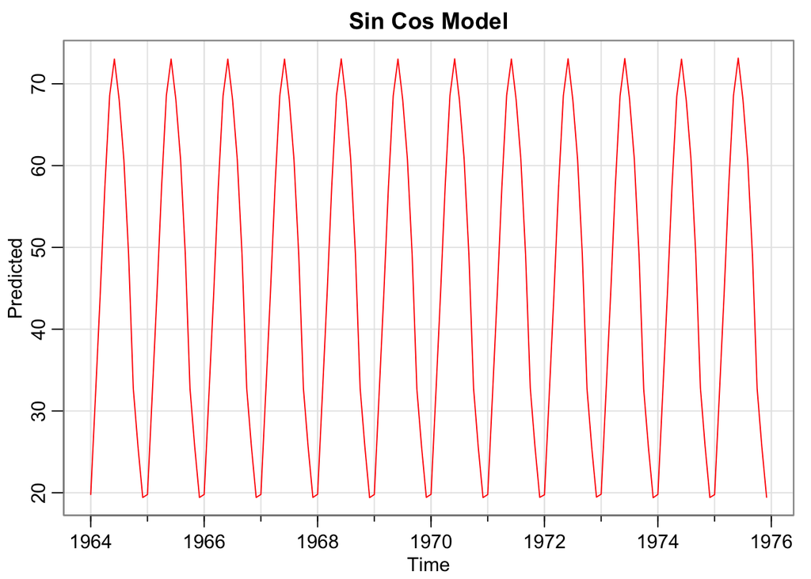

#### (ii) Graph the data, 𝑥𝑡, and superimpose the fitted values, say 𝑥̂𝑡, on the graph

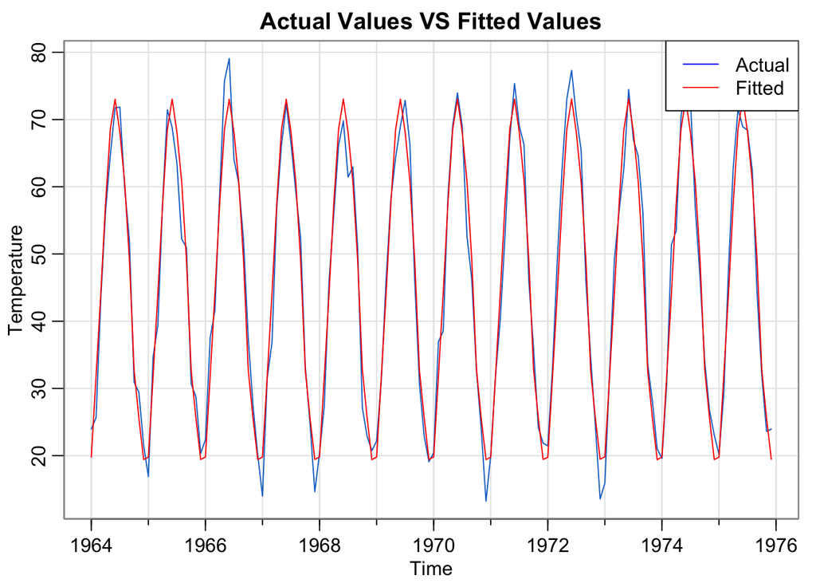

#### (iii) Examine the residuals, 𝑥𝑡−𝑥̂𝑡, and state your conclusions, Does it appear that the model fits the data well (do the residuals look white)? Does it appear that the residuals are a sample from a Normal distribution? Justify your answer.

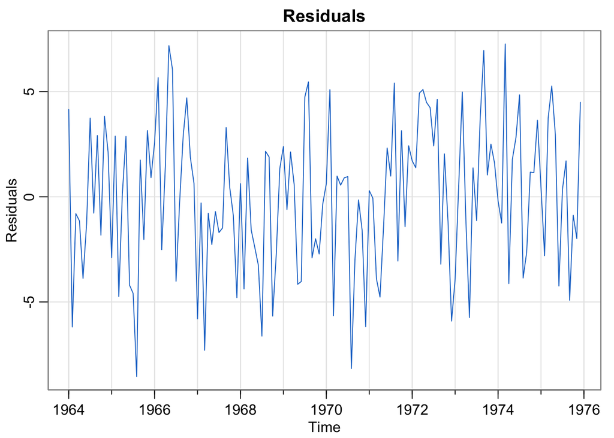

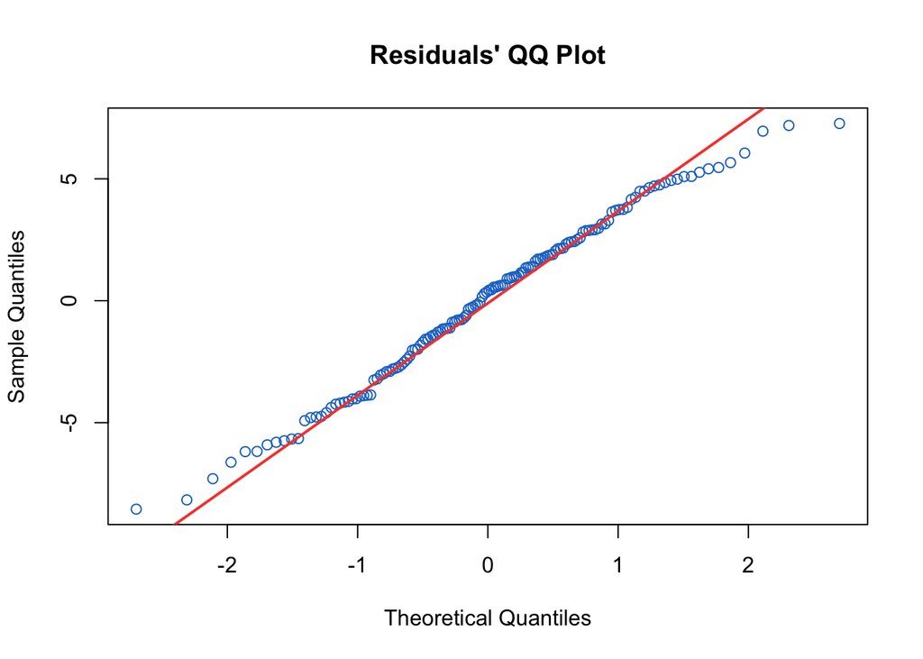

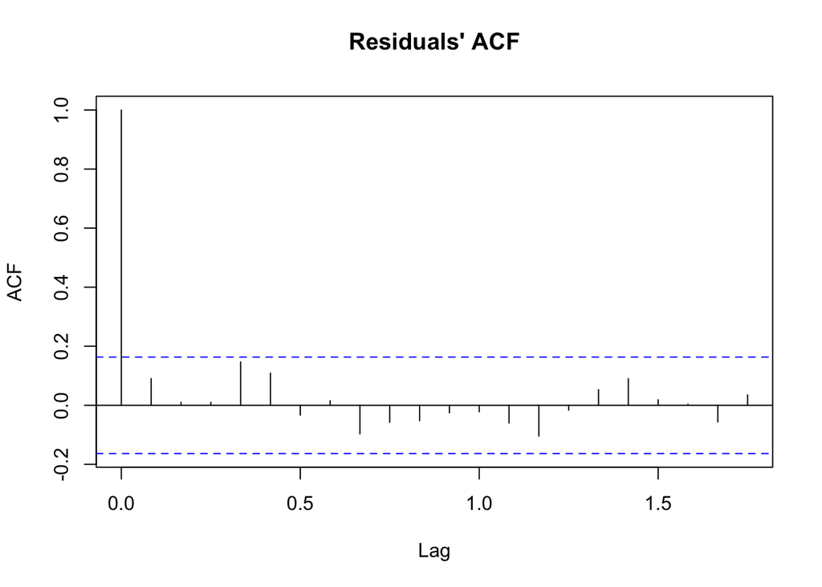

Same as in the first model, the first plot of the residuals shows what looks like uncorrelated white noise data without a pattern or seasonality. As observed in the QQ plot above the normality assumption looks reasonable. In addition, the ACf of the residuals shows that 95% of the autocorrelation spikes are within the blue lines which indicates there are no significant autocorrelations in the residuals. Thus the residuals look like white noise. The appereance of the residuals combined with the plot of Actual values vs fitted values indicate that the model fits the data well.

It is reasonable to say that the residuals seem to be sampled from the Normal distribution. To have a closer look at the comparison we can take a look at the following plots:

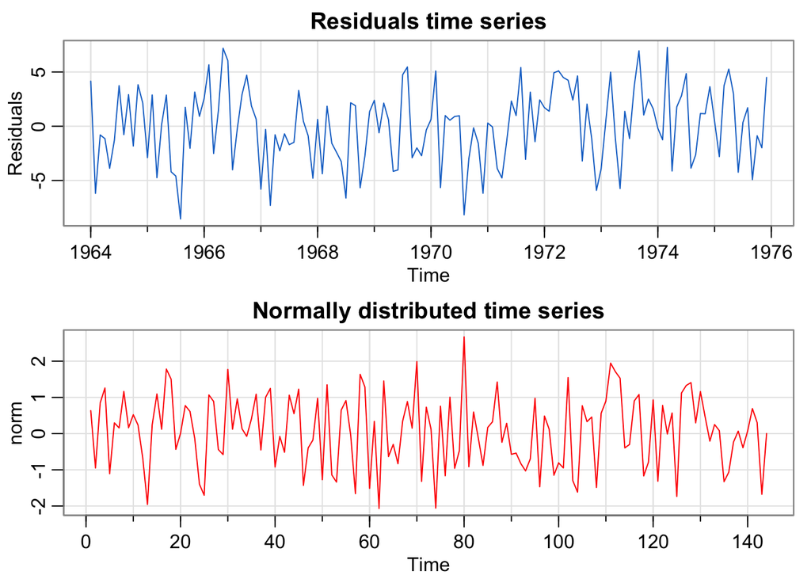

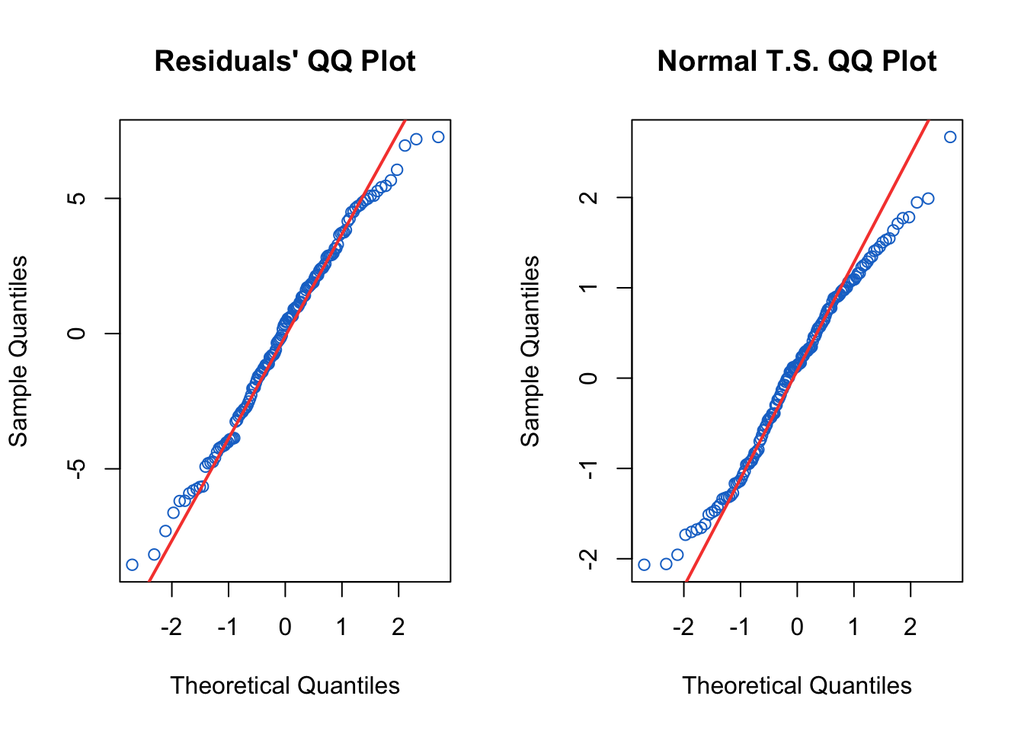

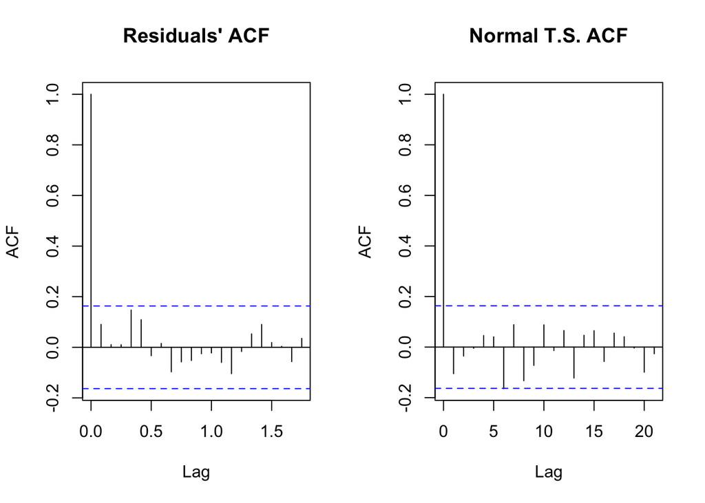

We can see the model residuals behave just as normally distributed white noise with mean zero and variance sigma-squared.

## Code Appendix

```r
# load the data
library(readr)
temperature <- read_csv("Project_1_Data.csv")

library(astsa)
# a)
temp = ts(data = temperature, frequency = 12, start = c(1964, 1), end = c(1975, 12))

tsplot(temp, col = 4,main = 'Temperature Time Series', ylab = 'Temperature')

acf(temp, main = 'ACF', lag = 50)

# b)
t = time(temp)
m = as.factor(cycle(temp))
model = lm(temp ~ -1 + m)

#model.matrix(model)
summary(model)
# b) (i)
coeff = summary(model)$coefficients[,1]
jan_feb = coeff['m2'] - coeff['m1']
feb_mar = coeff['m3'] - coeff['m2']
mar_apr = coeff['m4'] - coeff['m3']
apr_may = coeff['m5'] - coeff['m4']
may_jun = coeff['m6'] - coeff['m5']
jun_jul = coeff['m7'] - coeff['m6']
jul_aug = coeff['m8'] - coeff['m7']
aug_sep = coeff['m9'] - coeff['m8']
sep_oct = coeff['m10'] - coeff['m9']
oct_nov = coeff['m11'] - coeff['m10']
nov_dec = coeff['m12'] - coeff['m11']

avg_change = c(jan_feb, feb_mar, mar_apr, apr_may, may_jun, jun_jul, jul_aug, aug_sep, sep_oct, oct_nov, nov_dec)

months = c('January - February', 'February - March', 'March - April', 'April - May', 'May - June', 'June - July', 'July - August', 'August - September', 'September - October', 'October - November', 'Nobember - December')

temp_change = data.frame(months, avg_change)
rownames(temp_change) <- 1:nrow(temp_change)
temp_change
# b) (ii)
predicted = ts(predict(model), frequency = 12, start = c(1964, 1), end = c(1975, 12))

tsplot(temp, col = 4, main = 'Actual Values VS Fitted Values', ylab = 'Temperature')
lines(predicted, col = "red")
legend(x = 'topright', legend = c('Actual', 'Fitted'), col = c('blue', 'red'), lty = c(1,1))

residuals = ts(residuals(model), frequency = 12, start = c(1964, 1), end = c(1975, 12))

tsplot(residuals, col = 4, main = 'Residuals Plot', ylab = 'Residuals')

qqnorm(residuals, main = "Residuals QQ Plot", col = 4); qqline(residuals, col = 2, lwd = 2)

acf(residuals, lag = 50, main = 'Residuals\' ACF')

# c) (i)
t2 = 1:144

model2 = lm(temp ~ cos((2*pi*t2)/12) + sin((2*pi*t2)/12) + cos((2*2*pi*t2)/12) + sin((2*2*pi*t2)/12) + cos((2*3*pi*t2)/12) + sin((2*3*pi*t2)/12) + cos((2*4*pi*t2)/12) + sin((2*4*pi*t2)/12) +
cos((2*5*pi*t2)/12) + sin((2*5*pi*t2)/12) + cos((2*6*pi*t2)/12) + sin((2*6*pi*t2)/12))

summary(model2)

predicted2 = ts(predict(model2), frequency = 12, start = c(1964, 1), end = c(1975, 12))

tsplot(predicted2, col = 'red', main = 'Sin Cos Model', ylab = 'Predicted')

# c) (ii)
tsplot(temp, col = 4, main = 'Actual Values VS Fitted Values', ylab = 'Temperature')
lines(predicted2, col = "red")
legend(x = 'topright', legend = c('Actual', 'Fitted'), col = c('blue', 'red'), lty = c(1,1))

# c) (iii)
residuals2 = ts(residuals(model2), frequency = 12, start = c(1964, 1), end = c(1975, 12))
tsplot(residuals2, col = 4, main = 'Residuals', ylab = 'Residuals')

qqnorm(residuals2, main = "Residuals\' QQ Plot", col = 4); qqline(residuals2, col = 2, lwd = 2)

acf(residuals2, main = 'Residuals\' ACF')

residuals2 = ts(residuals(model2), frequency = 12, start = c(1964, 1), end = c(1975, 12))
norm = ts(rnorm(144))

par(mfrow = 2:1)
tsplot(residuals2, col = 4, ylab = 'Residuals', main = 'Residuals time series')
tsplot(norm, main = 'Normally distributed time series', col = 'red')

par(mfrow = 1:2)
qqnorm(residuals2, main = "Residuals\' QQ Plot", col = 4); qqline(residuals2, col = 2, lwd = 2)

qqnorm(norm, main = "Normal T.S. QQ Plot", col = 4); qqline(norm, col = 2, lwd = 2)

par(mfrow = 1:2)
acf(residuals2, main = 'Residuals\' ACF')
acf(norm, main = 'Normal T.S. ACF')
```